# TEDDYtools Manual

Ricardo Ramirez

5/3/2017

##### Description

*TEDDYtools* allow you to manipulate raw and processed metabolic and gene expression data. The objective is to homogenize the analysis that is performed by different persons.

TEDDYtoolsv2 is the most stable version. I will try to keep the code updated in my personal GitHub. There you can request changes and report bugs. (I am not making the data public)

TEDDYtools can be divided in 3 different folders and 1 make file

- **TargetFileCreation** : In this folder, raw data from GeneExpression, Metabolomics and FunctionalAnnotations are stored. Each folder contains a *TargetCreation* script that creates the Robjects stored in *GlobalData* folder
- **GlobalData**: R objects that summarize the annotation efforts in **TargetFileCreation**, these objects are the initial point in all of the analysis performed by anyone (In theory)
- **Suite**: Functions of TEDDYtools, divided by use
- **loadTEDDYtools.R**: make file with all the requirements and objects needed to run TEDDYtools. This script must be called to load TEDDYtools

##### Description of the data provided

##### * Inside TargetFileCreation:

**Gene Expression**

Raw gene expression matrix: Provided by Srikar

Raw gene expression matrix, inverse normalization: Provided by Leandro

Gene Expression Matrix Annotations: Set of files downloaded from TEDDY

**Metabolism**

Raw Positive Lipidomics: Provided by Leandro

Raw Negative Lipidomics: Provided by Leandro

Raw GCTOF: Provided by Leandro

Metabolomic Matrix Annotations: Generated in TargetFileCreation

**Annotations**

MSigDB raw files (cpg,biocarta,kegg,reactome,GOs,canonical,immune)

##### * As R objects in GlobalData:

**Gene Expression**

Raw gene expression matrix: Provided by Srikar (RAW) - **RAW_EXPMAT**

Raw gene expression matrix, inverse normalization: Provided by Leandro (NEEDS log2 transformation) - **RAW_EXPMATv2**

Gene Expression Matrix Annotations: Generated in TargetFileCreation, time is interpreted as positive (12 months before seroconversion = 12) **GEXtargets**

**Metabolism**

Raw Positive Lipidomics (log2 transformed, 0transformed to 0.01): Generated in TargetFileCreation - **posLipRAW_counts**

Raw Negative Lipidomics (log2 transformed, 0 transformed to 0.01): Generated in TargetFileCreation - **negLipRAW_counts**

Raw GCTOF (log2 transformed, 0 transformed to 0.01): Generated in TargetFileCreation - **GCTOFRAW_counts**

Metabolomic Matrix Annotations: Generated in TargetFileCreation, time is interpreted as positive (12 months before seroconversion = 12) - **MetabolicTargets**

**Annotations**

MSigDB annotations as a list (cpg,biocarta,kegg,reactome,GOs,canonical,immune) - **TEDDY_geneSets**

#### Installation

In *loadTEDDYtools.R* change the location of TEDDYtoolsV2 folder to your own pathway

```r
# The location of TEDDYtoolsV2
setwd("/Users/ricardoramirez/Dropbox (UFL)/myTEDDY_V2/TEDDYtoolsV2/")
```

After doing that, as a header in every analysis you perform, do the following to load TEDDYtools…

```r
# Home directory where all your results are going to be contained, TEDDYtools folder must be contained in it
homedir = "/Users/ricardoramirez/Desktop/TTools_demo/"
# Location of TEDDYtools make file
TEDDYtools = "/Users/ricardoramirez/Desktop/TTools_demo/loadTEDDYtools.R"
#Project location
source(TEDDYtools)
setwd(homedir)
```

### Working Examples using different functionalities of TEDDY tools

As a first example… Let’s work with Gene Expression.

The data in TEDDYtools is structured in 2 objects, Annotations (Targets) and Counts.

In our usual analysis we are interested in complete case-control pairs in at least one of the 5 time points we defined. To achieve this, you can use the following

```r
# Get the annotation of IA samples that have information in at least 1 of the 5 time-points asked
# Depending on your needs complete_case can be: strict(information at all time points), null(get all the data, regardless completeness), flexible(information in at least 1 time point)
LM_globalTargets = loadTargets_v2(SELdisease = "IA",time_point = c(12,9,6,3,0),
                                  complete_case = "flexible",targets = GEXtargets)
print(dim(LM_globalTargets))
```

```
## [1] 742  19
```

```r
print(head(LM_globalTargets[,1:5]))
```

```
##   sample_mask_id mask_id draw_dte_agedys CASE_IND case_endptage
## 1        9043430  991828             270        4           258
## 2        8054409  881791             258        4           258
## 3        4579409  838341             185        5           186
## 4        7794368  523984             186        5           186
## 5        4801892  813675            1270       12          1311
## 6        4365455  776923            1311       12          1311
```

Now, we can use the samples’s information to load,normalize and annotate the Gene Expression Matrix (Counts)

```r
RAW_EXPMAT = log2(RAW_EXPMATv2) #For the inversenorm matrix, log2 transformation is required
#ciNORM = Refers to X within normalization
#gNORM = Refers to outcome normalization (Keep it FALSE, not useful)
#annotation_column = "SYMBOL" or "ENTREZID"
LM_globalEXPMAT = getExprmat_v3(RAWEXPRMAT = RAW_EXPMAT,STARGETS = LM_globalTargets,
                                ciNORM = TRUE, gNORM = FALSE,
                                time = unique(LM_globalTargets$time),annotation_column = "SYMBOL")
print(LM_globalEXPMAT[1:5,1:5])
```

```
##             9043430     8054409     4579409     7794368     4801892
## EEF1A1   0.06297456 -0.06297456  0.11243708 -0.11243708  0.16604905
## SLC35E2  0.05925676 -0.05925676  0.16389309 -0.16389309  0.11039745
## EFCAB1   0.08260248 -0.08260248 -0.03074796  0.03074796 -0.27821839
## RPS28   -0.29491350  0.29491350  0.03525334 -0.03525334 -0.05612126
## IPO13   -0.13683941  0.13683941  0.09820160 -0.09820160  0.11577887
```

For Metabolomics the idea is similar, but there’s no way to obtain an annotated version of the matrix, so we need to do all the steps by hand

```r
# This gets the complete case-control pairs for the 5 time points selected
Filt_Targets = loadTargets_v2(SELdisease = "IA",time_point = c(12,9,6,3,0),complete_case = "flexible",targets = MetabolicTargets)

#Normalize Metabolomics Data
normMat = normGEX_v2(expMAT = negLipRAW_counts,targetTable = Filt_Targets,time = unique(Filt_Targets$time))

#Re order the data in order to have the sample_mask_ids in the same order of the Target File
normMat = normMat[,as.character(Filt_Targets$sample_mask_id)]
```

Also, as a reminder you can add more information to the annotations if you wish! In our case, I do it for the FAAB data

```r
FAAb = na.omit(read.delim(file = "/Users/ricardoramirez/Desktop/TTools_demo/SupData/wholedescriptivevars.txt", sep="\t",header = TRUE,stringsAsFactors = F)[,c("FirstAAbCC","sample_mask_id")])
colnames(FAAb) = c("FirstAAb","sample_mask_id")
LM_globalTargets = addFeatures(newDFdata = FAAb, TARGETS = LM_globalTargets, selCol = "sample_mask_id")
print(dim(LM_globalTargets))
```

```
## [1] 742  20
```

```r
print(colnames(LM_globalTargets))
```

```
##  [1] "sample_mask_id"      "mask_id"             "draw_dte_agedys"
##  [4] "CASE_IND"            "case_endptage"       "outcome"
##  [7] "disease"             "agemonth"            "case_endptage_month"
## [10] "time"                "agegroup"            "UF_MASKID"
## [13] "gender"              "race"                "race_ethnicity"
## [16] "season_of_birth"     "nbr_older_siblings"  "cc"
## [19] "country"             "FirstAAb"
```

There are other options of data manipulation

First let’s recover the information of all the cases

```r
Case_Annotations = filter(LM_globalTargets, outcome==1)
Case_Counts = LM_globalEXPMAT[,as.character(Case_Annotations$sample_mask_id)]
```

Do you want to know the mean/median expression of all the genes at a given time point?

```r
a = getGroupMean(groupcolumn = "time", stargets = Case_Annotations, sexprmat = Case_Counts)
print(head(a))
```

```
##         feature_name time_0                 time_12
## EEF1A1  "EEF1A1"     "-0.0139794076844874"  "0.01892615065432"
## SLC35E2 "SLC35E2"    "-0.0183817020880738"  "0.00816174757175557"
## EFCAB1  "EFCAB1"     "-0.00357458771160427" "-0.00387132865367315"
## RPS28   "RPS28"      "0.000843075283927193" "0.0374192124167836"
## IPO13   "IPO13"      "0.0150227519138822"   "-0.00129918393494839"
## PRSS41  "PRSS41"     "0.00393528595513554"  "-0.012159947193648"
##         time_9                 time_3
## EEF1A1  "0.00144403110601206"  "0.00282110560682246"
## SLC35E2 "-0.0263319919222593"  "-0.0107120650108011"
## EFCAB1  "-0.00960550936598804" "-0.00730833924513593"
## RPS28   "0.00625705020374471"  "0.0272266411453422"
## IPO13   "-0.0017786699561642"  "0.0214858434133243"
## PRSS41  "-0.00879962510635183" "-0.00241298261753009"
##         time_6
## EEF1A1  "-0.0110829912065151"
## SLC35E2 "-0.0156165478587575"
## EFCAB1  "-0.00044829624629342"
## RPS28   "-0.0139002763599102"
## IPO13   "-0.00173410708399447"
## PRSS41  "-0.0207887542528046"
```

```r
b = getGroupMedian(groupcolumn = "time", stargets = Case_Annotations, sexprmat = Case_Counts)
print(head(b))
```

```
##                time_0       time_3       time_6       time_9      time_12
## EEF1A1  -0.0209273978 -0.002291152 -0.015494465  0.011122142  0.011073451
## SLC35E2 -0.0019805011 -0.004221827 -0.025506460  0.023471458 -0.057153870
## EFCAB1  -0.0046661628 -0.012010284  0.005400062 -0.006656306 -0.005593981
## RPS28    0.0005858384  0.028671535 -0.005912755  0.011705421  0.045808708
## IPO13    0.0118841271  0.016048042  0.014084396 -0.006719098 -0.008752767
## PRSS41   0.0026374500 -0.003536046 -0.002554402 -0.008131288 -0.017877139
```

Do you want to know the changes in mean expression in the 4 intervals defined in our analysis?

```r
a = get_ChangeMatrix(CountMat = Case_Counts,AnnotationMat = Case_Annotations)
print(head(a))
```

```
##                  3-0          6-3           9-6         12-9
## EEF1A1   0.016800513 -0.013904097  1.252702e-02  0.017482120
## SLC35E2  0.007669637 -0.004904483 -1.071544e-02  0.034493739
## EFCAB1  -0.003733752  0.006860043 -9.157213e-03  0.005734181
## RPS28    0.026383566 -0.041126918  2.015733e-02  0.031162162
## IPO13    0.006463091 -0.023219950 -4.456287e-05  0.000479486
## PRSS41  -0.006348269 -0.018375772  1.198913e-02 -0.003360322
```

Do you want to create a patient/genes/time matrix?

```r
#melType: case, control or both
a = meltCountMatrix(targetDF = Case_Annotations,
                    countMat = Case_Counts,
                    selFeat = rownames(Case_Counts)[1:5],meltType = "case")
print(a[1:4,c(1,2,6,7)])
```

```
##          EEF1A1_t0  SLC35E2_t0 EEF1A1_t3 SLC35E2_t3
## 881791 -0.06297456 -0.05925676        NA         NA
## 523984 -0.11243708 -0.16389309        NA         NA
## 776923 -0.16604905 -0.11039745        NA         NA
## 518390  0.16105533 -0.29614145        NA         NA
```

### Visual Manager

Different plots can be done to a Target-Count object (GENEX,Metabolomics,Dietary Biomarkers,…)

Let’s evaluate the time-specific difference in expression of a given gene…

Based on outcome

```r
genedynamics(EXPRMAT = LM_globalEXPMAT,GENES = "MTOR",
             STARGETS = LM_globalTargets,TRSH = 0.05,
             SIGNIFICANCE = FALSE ,CASE_CONTROL = FALSE)
```

```
## [1] "MTOR"
```

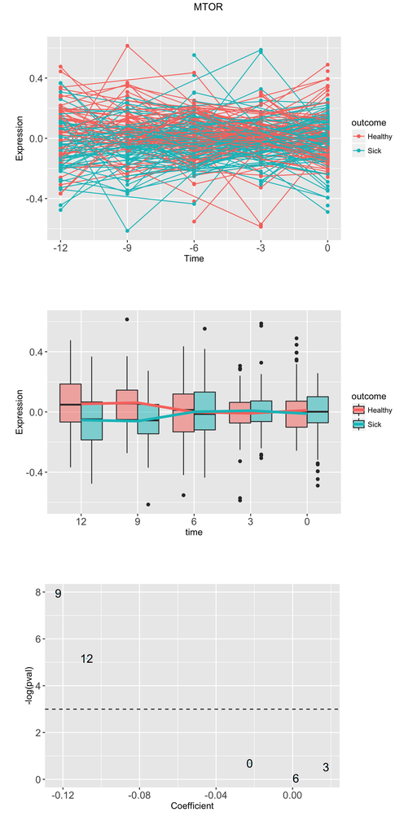

```
##   TIME GENE         COEF        PVAL
## 1    0 MTOR -0.022334359 0.502068875
## 2   12 MTOR -0.107624834 0.005727441
## 3    9 MTOR -0.122392850 0.000350341
## 4    3 MTOR  0.017564301 0.587039153
## 5    6 MTOR  0.001846914 0.950540585
```

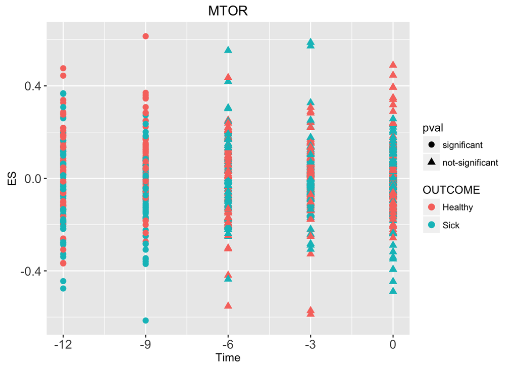

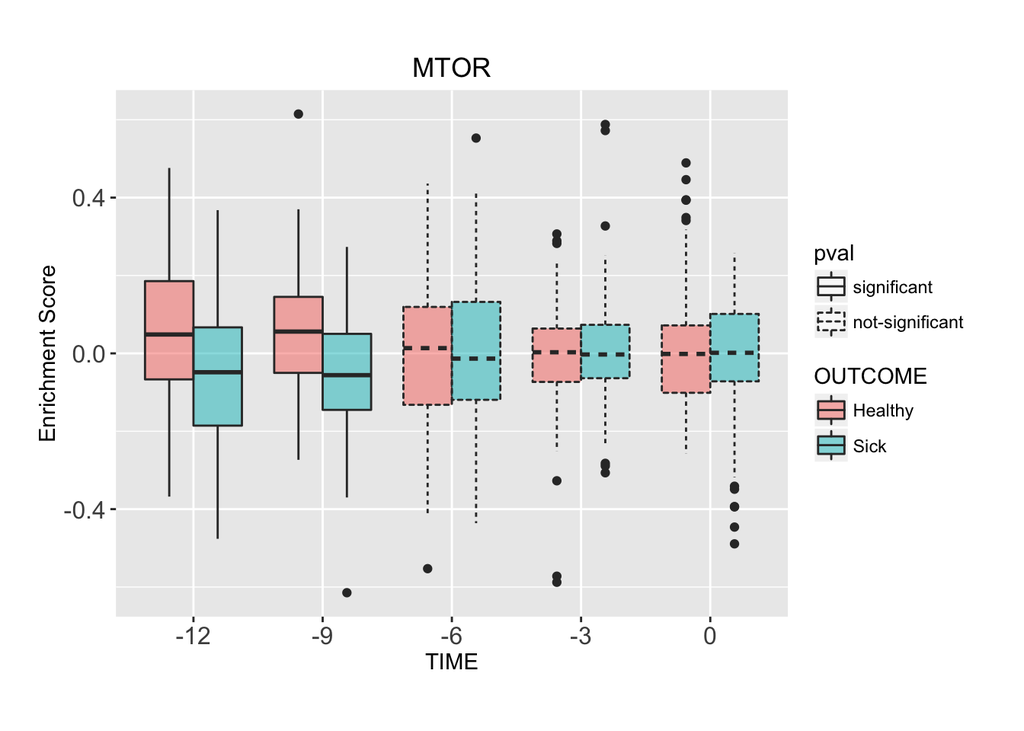

```r
#Annotations and counts must be in the same order
plotES(ES_list = LM_globalEXPMAT["MTOR",],sigTargets = LM_globalTargets,TRSH=0.05,main_title = "MTOR")
```

*plotgenetrajectory*, *plotgenetrajectorybp* can plot similar results, take a look at the documentation inside the functions

Heatmaps can also be created using TEDDYtools

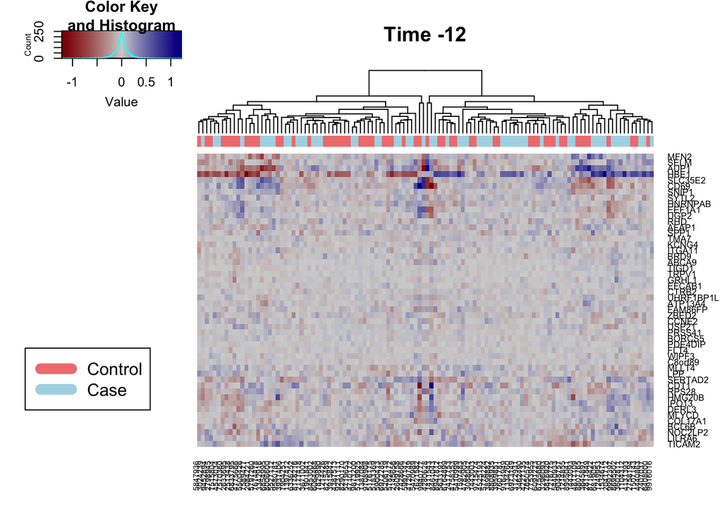

```r
#Annotations and counts must be in the same order
plotHMps(genes = rownames(LM_globalEXPMAT)[1:50],expmat = LM_globalEXPMAT,targetdf = LM_globalTargets,time.point = c(12))
```

MDS plots are also implemented

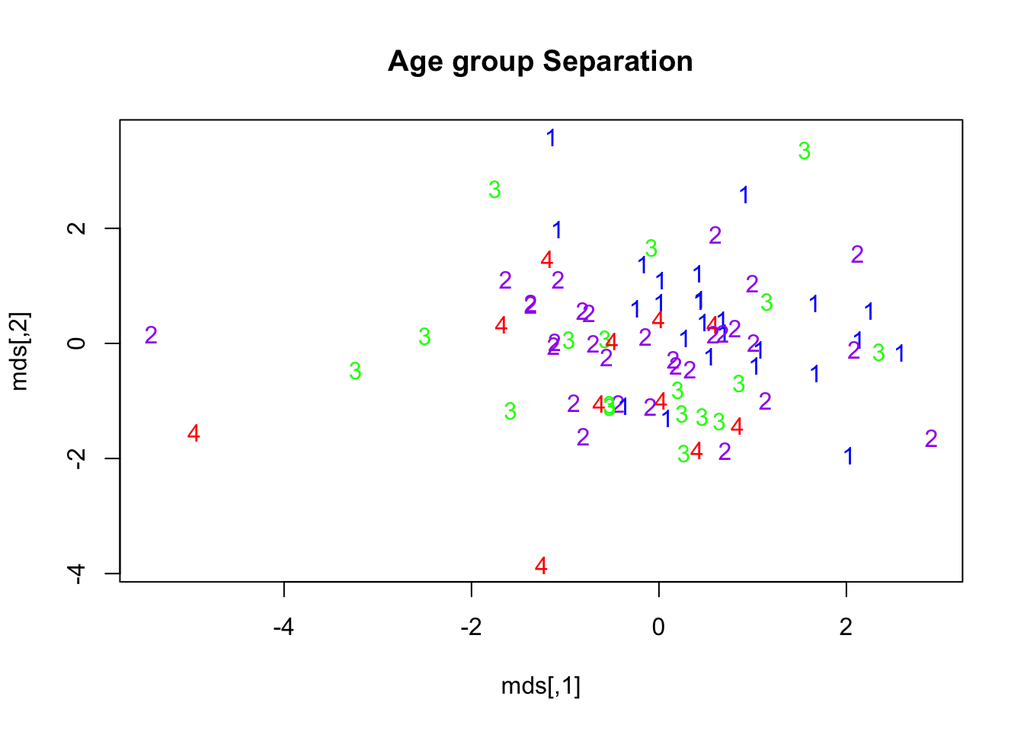

```r
PatientMatrix = meltCountMatrix(targetDF = Case_Annotations,
                    countMat = Case_Counts,
                    selFeat = rownames(Case_Counts)[1:150],meltType = "case")

plot_MDS_Tv_v2(meltMat = PatientMatrix,targetDF = Case_Annotations,main = "Age group Separation",GroupColumn = "agegroup")
```

### Differential Expression Analysis

There are two types of analysis: time-specific and time course. Time-specific DEAs analyze every time point in an independent manner, while time course analysis try to analyze dynamics as a whole (models the changes).

**Time Specific**

The only thing you need to perform a time specific analysis is a TargetTable and a CountMatrix, *runTEDDYlimma_basic* and *fitGLM_v2*, use the outcome column in your TargetTable to perform the analysis (you can only have 1’s or 0’s, where 1 will represent the reference). Given that it ignores the time, it is NECESSARY to filter your counts to have only the information of 1 timepoint.

```r
#Using Limma
Time0_samples = filter(LM_globalTargets,time==0)
Time0_counts = LM_globalEXPMAT[,as.character(Time0_samples$sample_mask_id)]
Time0_DEA = runTEDDYlimma_basic(stargets = Time0_samples,sEXPMAT = Time0_counts)
print(head(Time0_DEA))
```

```
##               logFC       AveExpr         t      P.Value    adj.P.Val
## BAK1     0.13849954  2.176908e-17  6.538692 4.847812e-10 6.174379e-06
## ZNF782  -0.11064985 -8.707632e-18 -6.506137 5.802443e-10 6.174379e-06
## SZRD1    0.08076366  3.047671e-17  6.308666 1.705848e-09 1.058082e-05
## ADTRP   -0.18402147 -5.224579e-17 -6.280258 1.988690e-09 1.058082e-05
## TMEM254 -0.08261988  3.918434e-17 -5.950253 1.143862e-08 4.868736e-05
## DIS3    -0.12463141 -2.176908e-17 -5.825851 2.176850e-08 7.659350e-05
##                 B
## BAK1    12.501511
## ZNF782  12.328169
## SZRD1   11.288926
## ADTRP   11.141178
## TMEM254  9.458228
## DIS3     8.840251
```

```r
#Filter results
TSign = filterLimmaGLSv3(GLS = Time0_DEA,pTRSH = 0.05,FC_col = "logFC")
print(summary(TSign))
```

```
##      Length Class  Mode
## up   1024   -none- character
## down 1412   -none- character
```

```r
#Using Linear Models from R
Time0_DEA = fitGLM_v2(cMAT = Time0_counts[1:100,],cTargets = Time0_samples)
print(head(Time0_DEA))
```

```
##   Hallmark  Coefficient      P_val adj_P_val
## 1   EEF1A1 -0.027958815 0.07427807 0.2321190
## 2  SLC35E2 -0.036763404 0.16830677 0.4102462
## 3   EFCAB1 -0.007149175 0.55774837 0.7562373
## 4    RPS28  0.001686151 0.94217244 0.9614004
## 5    IPO13  0.030045504 0.08058636 0.2442011
## 6   PRSS41  0.007870572 0.50197301 0.7070042
```

```r
#Filter results
TSign = filterGLM(GLMres = Time0_DEA,THRS = .5)
print(summary(TSign))
```

```
##      Length Class  Mode
## up   25     -none- character
## down 26     -none- character
```

I have coded a function that allows you to create combinations

```r
AgeFeatures = list("agegroup"=unique(LM_globalTargets$agegroup))

Age_signatures_limma_results = getSignatures(cMAT = LM_globalEXPMAT,targetMAT = LM_globalTargets,
                                             Features = AgeFeatures,time = c(0,3,6,9,12),
                                             g.pval = 0.05,s.pval=0.05,model_type = "limma")

print(summary(Age_signatures_limma_results))
```

[output not shown]

**Time Course Analysis**

This is only implemented in limma, Age0=T if you don’t have information at time 12 (agegroup 1)

```r
TC_results = runTimeCourse_test(countMAT = LM_globalEXPMAT,annotationDF = LM_globalTargets,compCOL = "outcome",Age0 = F)
print(head(TC_results$global))
```

```
##               Dif03       Dif36        Dif69      Dif129       AveExpr
## ALG1L2  -0.03987457  0.06452328 -0.106400382 -0.03907959  2.513713e-17
## SLC10A5 -0.07267597  0.11077654  0.033418352 -0.03561269  1.436407e-17
## MIR195  -0.05767196  0.08591690 -0.099733869  0.03641440 -2.633413e-17
## MS4A15   0.04006335 -0.08419170  0.005872476  0.08456748  2.753114e-17
## WHAMMP2  0.03534536  0.02194030 -0.101858681  0.03288520  1.017455e-17
## FOXF2    0.08452255 -0.05148234  0.060786413 -0.05955419 -1.316707e-17
##                 F      P.Value    adj.P.Val
## ALG1L2  17.427401 1.134246e-13 2.413903e-09
## SLC10A5 12.376152 9.560468e-10 1.017329e-05
## MIR195   9.540998 1.595040e-07 8.460687e-04
## MS4A15   9.533870 1.615716e-07 8.460687e-04
## WHAMMP2  9.406175 2.035008e-07 8.460687e-04
## FOXF2    9.318268 2.385308e-07 8.460687e-04
```

### Enrichment Analysis

**Hypergeometric tests**, **GSEA** and **PIANO** were implemented to perform different enrichment analysis

GSEA holds for Gene Set Enrichment Analysis, which is based in a Kolmogorov-Smirnoff statistic coupled to a running sum

Scripts were recovered from GSEA’s web page and adapted to perform basic analysis

In the most basic analysis it requires an expression matrix and a collection of gene sets

```r
ExCounts = LM_globalEXPMAT[,1:5]
print(ExCounts[1:5,1:5])
```

```
##             9043430     8054409     4579409     7794368     4801892
## EEF1A1   0.06297456 -0.06297456  0.11243708 -0.11243708  0.16604905
## SLC35E2  0.05925676 -0.05925676  0.16389309 -0.16389309  0.11039745
## EFCAB1   0.08260248 -0.08260248 -0.03074796  0.03074796 -0.27821839
## RPS28   -0.29491350  0.29491350  0.03525334 -0.03525334 -0.05612126
## IPO13   -0.13683941  0.13683941  0.09820160 -0.09820160  0.11577887
```

```r
ExSets = TEDDY_geneSets$MSIGDB_HMARKS[c(1:5)]
ExFMat = getFunctionMatrix_v2(eMat = ExCounts,eTargets = c(),Signature_Dict = ExSets,weighted = FALSE)
```

```
## [1] "PANCREAS_BETA_CELLS"
## [1] "TGF_BETA_SIGNALING"
## [1] "IL2_STAT5_SIGNALING"
## [1] "BILE_ACID_METABOLISM"
## [1] "MITOTIC_SPINDLE"
```

```r
print(ExFMat$ES[1:5,1:5])
```

```
##                        9043430   8054409   4579409   7794368   4801892
## PANCREAS_BETA_CELLS   0.105540 -0.105540  0.063862 -0.063862 -0.124350
## TGF_BETA_SIGNALING    0.262550 -0.262550 -0.116470  0.116470  0.274600
## IL2_STAT5_SIGNALING   0.148340 -0.148340 -0.165690  0.165690  0.089854
## BILE_ACID_METABOLISM  0.072968 -0.072968 -0.068465  0.068465  0.083504
## MITOTIC_SPINDLE      -0.054055  0.054055  0.084335 -0.084335  0.095155
```

If *weighted*==TRUE, then you’ll need to provide an annotation table with an “outcome” column, which is going to be used to assign a weight to each gene based on a basic T-test

For the **Hypergeometric Test** I’ll use the selection from the n-PLS-DA as an example

```r
PLS_genes = read.delim("/Users/ricardoramirez/Desktop/TTools_demo/SupData/PLS_results/ClusterList/PLS_selection.txt",
                       stringsAsFactors = F,header = F)[,1]

HyperRes = GSE_analysis(geneList = PLS_genes,Annotation_DB = TEDDY_geneSets$REACTOME)

print(HyperRes[6:7,])
```

```
##                                       GenesInPathway GenesInList
## TWIK related potassium channel (TREK)              3           2
## The proton buffering model                         3           2
##                                         GeneNames             p_value
## TWIK related potassium channel (TREK) KCNK2,KCNK4 0.00365658026327381
## The proton buffering model              UCP3,UCP1 0.00365658026327381
##                                            corr_p_value
## TWIK related potassium channel (TREK) 0.704348773213118
## The proton buffering model            0.704348773213118
```

**PIANO** requires gene level statistics (results from limma) and a specific gene set collection.

```r
runMultiGSA(GSC = melt(TEDDY_geneSets$MSIGDB_HMARKS),GLS = LimmaResults)
```

### Perspectives

To see how these tools are used as a whole, you can take a look at the complete analysis of Gene Expression Data

One of my objectives was to make TEDDYtools a collaborative space in which all of us could share our code and avoid repeating functions that were implemented by someone else.

Feel free to report any bug and add more functionalities.